# sealey-briana-ADA-homework-2

## Challenge 3

```r
f <- "https://raw.githubusercontent.com/difiore/ADA-datasets/master/zombies.csv"
d <- read_csv(f, col_names = TRUE)
str(d)
```

```
## Classes 'tbl_df', 'tbl' and 'data.frame':    1000 obs. of  10 variables:
##  $ id                : int  1 2 3 4 5 6 7 8 9 10 ...
##  $ first_name        : chr  "Sarah" "Mark" "Brandon" "Roger" ...
##  $ last_name         : chr  "Little" "Duncan" "Perez" "Coleman" ...
##  $ gender            : chr  "Female" "Male" "Male" "Male" ...
##  $ height            : num  62.9 67.8 72.1 66.8 64.7 ...
##  $ weight            : num  132 146 153 130 132 ...
##  $ zombies_killed    : int  2 5 1 5 4 1 0 4 9 2 ...
##  $ years_of_education: int  1 3 1 6 3 4 4 0 3 3 ...
##  $ major             : chr  "medicine/nursing" "criminal justice administration" "education" "energy studies" ...
##  $ age               : num  17.6 22.6 21.9 18.2 21.1 ...
##  - attr(*, "spec")=List of 2
##   ..$ cols   :List of 10
##   .. ..$ id                : list()
##   .. .. ..- attr(*, "class")= chr  "collector_integer" "collector"
##   .. ..$ first_name        : list()
##   .. .. ..- attr(*, "class")= chr  "collector_character" "collector"
##   .. ..$ last_name         : list()
##   .. .. ..- attr(*, "class")= chr  "collector_character" "collector"
##   .. ..$ gender            : list()
##   .. .. ..- attr(*, "class")= chr  "collector_character" "collector"
##   .. ..$ height            : list()
##   .. .. ..- attr(*, "class")= chr  "collector_double" "collector"
##   .. ..$ weight            : list()
##   .. .. ..- attr(*, "class")= chr  "collector_double" "collector"
##   .. ..$ zombies_killed    : list()
##   .. .. ..- attr(*, "class")= chr  "collector_integer" "collector"
##   .. ..$ years_of_education: list()
##   .. .. ..- attr(*, "class")= chr  "collector_integer" "collector"
##   .. ..$ major             : list()
##   .. .. ..- attr(*, "class")= chr  "collector_character" "collector"
##   .. ..$ age               : list()
##   .. .. ..- attr(*, "class")= chr  "collector_double" "collector"
##   ..$ default: list()
##   .. ..- attr(*, "class")= chr  "collector_guess" "collector"
##   ..- attr(*, "class")= chr "col_spec"
```

```r
#Question 1
(pop1 <- favstats(~height, data = d))
```

```
##       min       Q1   median       Q3     max    mean       sd    n missing
##  54.14948 64.67901 67.50216 70.38313 80.5298 67.6301 4.310126 1000       0
```

```r
(pop2 <- favstats(~weight, data = d))
```

```
##       min       Q1   median       Q3      max     mean       sd    n missing
##  90.29148 131.8086 142.8916 156.2823 210.7895 143.9075 18.40106 1000       0
```

```r
(pop3 <- favstats(~age, data = d))
```

```
##       min       Q1   median       Q3      max     mean       sd    n missing
##  10.66381 18.06501 19.90145 21.94006 29.59488 20.04696 2.965066 1000       0
```

```r
(pop4 <- favstats(~zombies_killed, data = d))
```

```
##  min Q1 median Q3 max  mean       sd    n missing
##    0  2      3  4  11 2.992 1.748426 1000       0
```

```r
(pop5 <- favstats(~years_of_education, data = d))
```

```
##  min Q1 median Q3 max  mean       sd    n missing
##    0  2      3  4   8 2.996 1.676543 1000       0
```

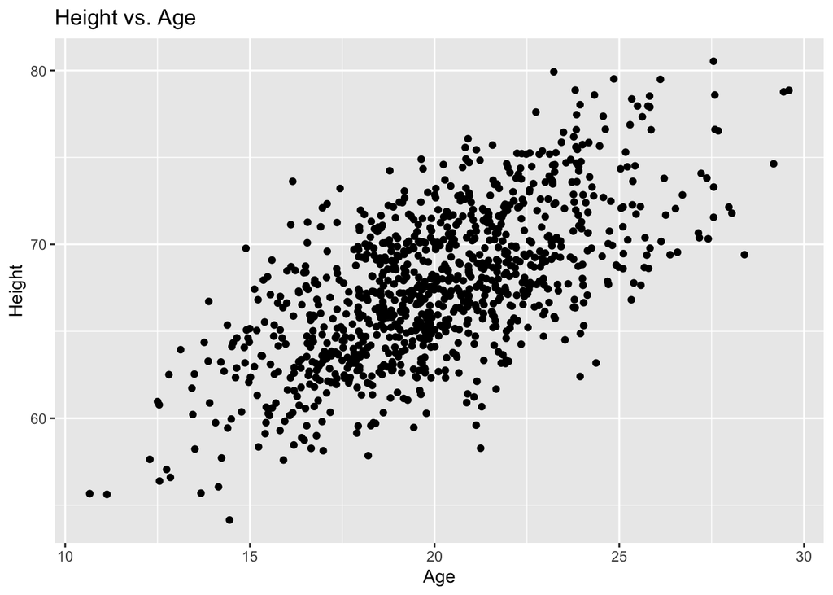

```r
#Question 2, scatterplots of height and weight in relation to age
#height
ggplot(data = d) + aes(x = age, y = height) +
     geom_point(na.rm = TRUE) +
  ggtitle(label = "Height vs. Age") +
  ylab(label = "Height") +
  xlab(label = "Age")
```

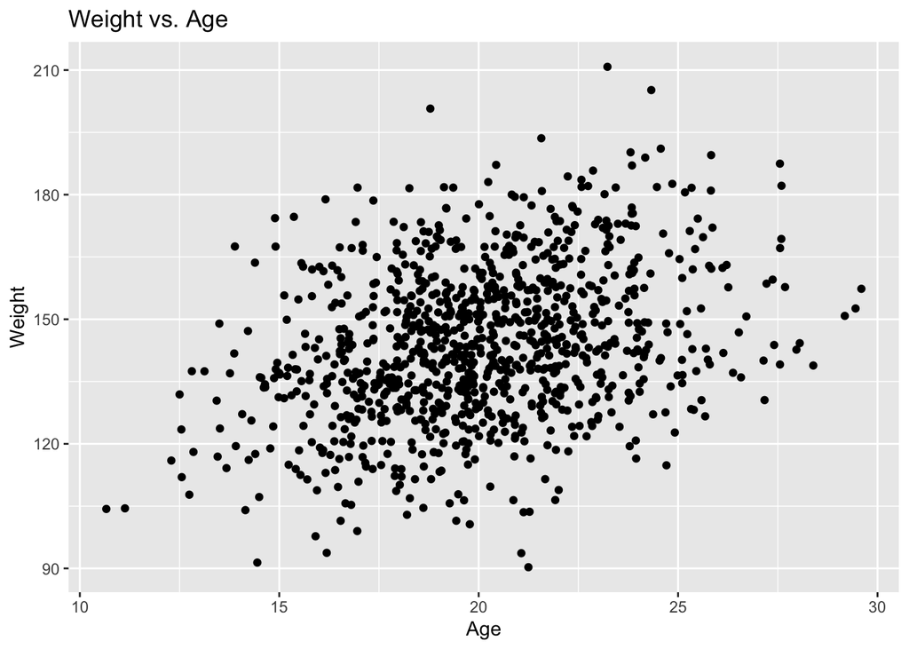

```r
#weight
ggplot(data = d) + aes(x = age, y = weight) +
     geom_point(na.rm = TRUE) +
  ggtitle(label = "Weight vs. Age") +
  ylab(label = "Weight") +
  xlab(label = "Age")
```

#### Only looking at the two graphs, both height and weight appear to be positively correlated to age

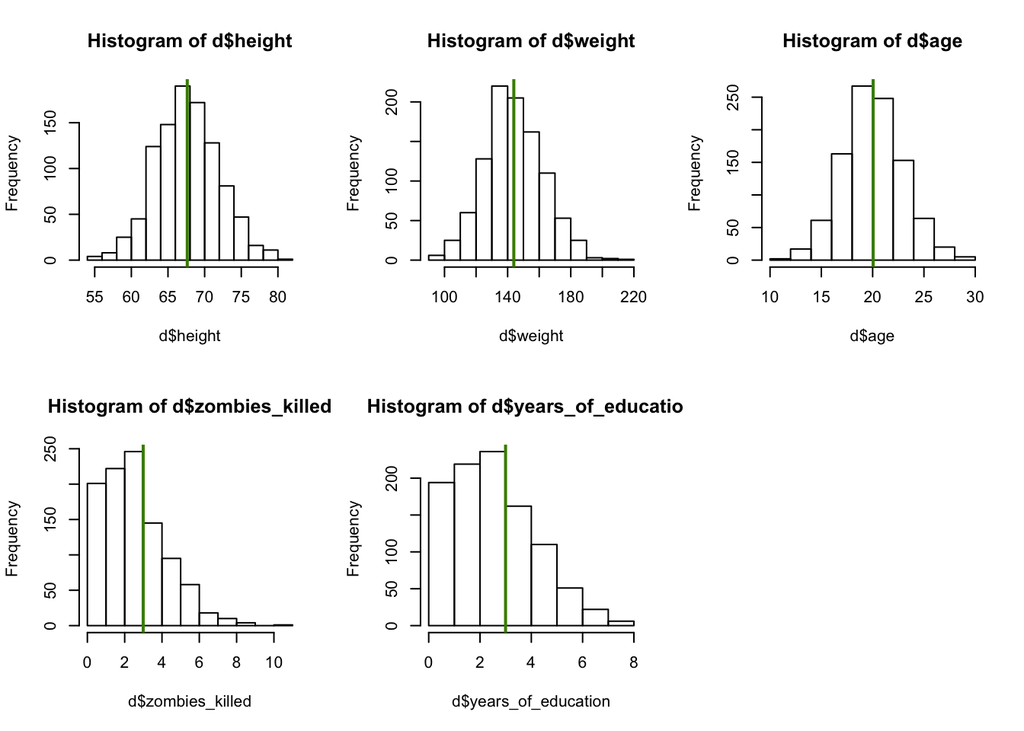

```r
#Question 3, histograms and Q-Q plots
#Histograms
par(mfrow = c(2,3))
hist(x =d$height)
abline(v = mean(d$height), col = "chartreuse4", lwd = 2)
hist(x =d$weight)
abline(v = mean(d$weight), col = "chartreuse4", lwd = 2)
hist(x =d$age)
abline(v = mean(d$age), col = "chartreuse4", lwd = 2)
hist(x =d$zombies_killed) #skewed
abline(v = mean(d$zombies_killed), col = "chartreuse4", lwd = 2)
hist(x =d$years_of_education) #skewed
abline(v = mean(d$years_of_education), col = "chartreuse4", lwd = 2)
#Q-Q Plots
par(mfrow = c(2,3))
```

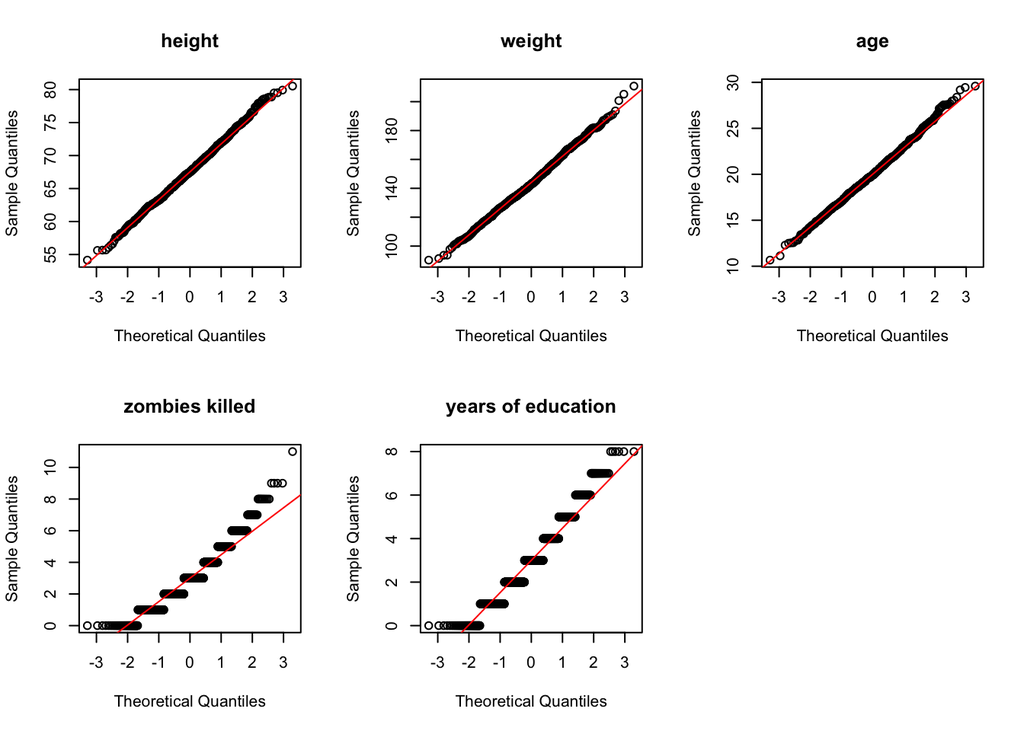

```r
qqnorm(d$height, main = "height")
qqline(d$height, col = "red")
qqnorm(d$weight, main = "weight")
qqline(d$weight, col = "red")
qqnorm(d$age, main = "age")
qqline(d$age, col = "red")
qqnorm(d$zombies_killed, main = "zombies killed") #staircase
qqline(d$zombies_killed, col = "red")
qqnorm(d$years_of_education, main = "years of education") #staircase
qqline(d$years_of_education, col = "red")
par(mfrow = c(1,1))
```

#### The number of zombies killed and the years of education appear to not be normallly distributed. The histograms are skewed and the qqplots are nonlinear.

```r
#Question 4
n <- 30
alpha <- 0.05
s <- sample_n(d, size = n, replace = FALSE)

#For height
s_height <- favstats(~height, data = s)
s_height
```

```
##       min       Q1   median       Q3      max     mean       sd  n missing
##  62.36085 66.88349 67.63109 69.96346 75.18322 68.34431 3.197332 30       0
```

```r
#CF height
ci_height <- mean(s$height) + c(-1, 1) * qnorm(1 - alpha / 2) * sd(s$height)/sqrt(n)
ci_height
```

```
## [1] 67.20018 69.48844
```

```r
#For weight
s_weight <- favstats(~weight, data = s)
s_weight
```

```
##       min      Q1   median       Q3      max     mean       sd  n missing
##  126.6091 138.133 144.8809 155.6641 177.2801 147.6068 13.37966 30       0
```

```r
#CF weight
ci_weight <- mean(s$weight) + c(-1, 1) * qnorm(1 - alpha / 2) * sd(s$weight)/sqrt(n)
ci_weight
```

```
## [1] 142.8190 152.3945
```

```r
#For age
s_age <- favstats(~age, data = s)
s_age
```

```
##       min       Q1   median      Q3      max     mean       sd  n missing
##  15.01671 18.44013 20.00311 20.8614 23.90774 19.71495 2.065417 30       0
```

```r
#CF age
ci_age <- mean(s$age) + c(-1, 1) * qnorm(1 - alpha / 2) * sd(s$age)/sqrt(n)
ci_age
```

```
## [1] 18.97586 20.45404
```

```r
#For zombies killed
#sample for zombies_killed = s_zk
s_zk <- favstats(~zombies_killed, data = s)
s_zk
```

```
##  min   Q1 median   Q3 max     mean       sd  n missing
##    0 1.25    2.5 3.75   7 2.766667 1.813424 30       0
```

```r
#CF zk
ci_zk <- mean(s$zombies_killed) + c(-1, 1) * qnorm(1 - alpha / 2) * sd(s$zombies_killed)/sqrt(n)
ci_zk
```

```
## [1] 2.117753 3.415580
```

```r
#For years of educaton = yoe
s_yoe <- favstats(~years_of_education, data = s)
s_yoe
```

```
##  min Q1 median Q3 max     mean       sd  n missing
##    1  2      3  4   6 3.066667 1.412587 30       0
```

```r
#CF yoe
ci_yoe <- mean(s$years_of_education) + c(-1, 1) * qnorm(1 - alpha / 2) * sd(s$years_of_education)/sqrt(n)
ci_yoe
```

```
## [1] 2.561188 3.572145
```

```r
#Question 5
reps <- 99
n <- 30
s <- sample_n(d, size = n, replace = FALSE)

#For height
s_heightsd <- do(reps) * mean(~height, data = sample_n(d, size = n, replace = FALSE))
s_height2 <- favstats(~mean, data = s_heightsd)
s_height2_sd <- favstats(~mean, data = s_heightsd)$sd*sqrt(n)
s_height2
```

```
##       min       Q1   median       Q3      max     mean        sd  n missing
##  65.83713 67.04313 67.79507 68.27059 69.36762 67.69744 0.7956866 99       0
```

```r
#For weight
s_weightsd <- do(reps) * mean(~weight, data = sample_n(d, size = n, replace = FALSE))
s_weight2 <- favstats(~mean, data = s_weightsd)
s_weight2
```

```
##       min       Q1   median       Q3      max     mean       sd  n missing
##  136.3836 141.8694 143.9984 146.2107 152.9483 144.1631 3.302328 99       0
```

```r
#For age
s_agesd <- do(reps) * mean(~age, data = sample_n(d, size = n, replace = FALSE))
s_age2 <- favstats(~mean, data = s_agesd)
s_age2
```

```
##       min       Q1   median       Q3      max     mean        sd  n missing
##  18.91567 19.78046 20.11661 20.38006 21.38343 20.08914 0.5170928 99       0
```

```r
#For zombies killed
#sample for zombies_killed = s_zk
s_zksd <- do(reps) * mean(~zombies_killed, data = sample_n(d, size = n, replace = FALSE))
s_zk2 <- favstats(~mean, data = s_zksd)
s_zk2
```

```
##       min       Q1   median   Q3      max     mean        sd  n missing
##  2.366667 2.733333 2.933333 3.25 3.766667 2.991246 0.3354553 99       0
```

```r
#For years of educaton
s_yoesd <- do(reps) * mean(~years_of_education, data = sample_n(d, size = n, replace = FALSE))
s_yoe2 <- favstats(~mean, data = s_yoesd)
s_yoe2
```

```
##       min       Q1   median  Q3 max     mean        sd  n missing
##  2.066667 2.766667 2.933333 3.2 3.8 2.964983 0.3078848 99       0
```

```r
#population variance eq
pop_var <- function(x) {
  sum((x - mean(x))^2) / (length(x))
}

#calculating SE's using pop var
pop_height <- sqrt(pop_var(d$height) / 1000)
pop_weight <- sqrt(pop_var(d$weight) / 1000)
pop_age <- sqrt(pop_var(d$age) / 1000)
pop_zk <- sqrt(pop_var(d$zombies_killed) / 1000)
pop_yoe <- sqrt(pop_var(d$years_of_education) / 1000)

#Combining them to make it easier to see across calculations
cbind(pop_height, s_height$sd, s_height2$sd)
```

```
##      pop_height
## [1,]    0.13623 3.197332 0.7956866
```

```r
cbind(pop_weight, s_weight$sd, s_weight2$sd)
```

```
##      pop_weight
## [1,]  0.5816016 13.37966 3.302328
```

```r
cbind(pop_age, s_age$sd, s_age2$sd)
```

```
##         pop_age
## [1,] 0.09371671 2.065417 0.5170928
```

```r
cbind(pop_zk, s_zk$sd, s_zk2$sd)
```

```
##          pop_zk
## [1,] 0.05526243 1.813424 0.3354553
```

```r
cbind(pop_yoe, s_yoe$sd, s_yoe2$sd)
```

```
##         pop_yoe
## [1,] 0.05299041 1.412587 0.3078848
```

#### The estimated SE is smaller than the sample distribution and single sample SE. This is to be expected because the sample size is at 1000, thus decreasing the SE because our estimation of the mean is more certain. The sample distribution SE is smaller than the sample SE because the number of replicates are so great (100 vs. 1), thus the estimation of the mean is less variable.

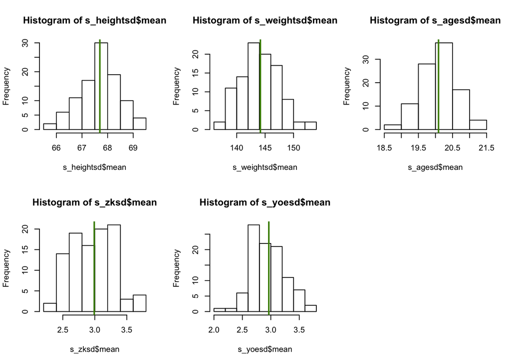

```r
#Histograms
par(mfrow= c(2,3))
hist(s_heightsd$mean) #as expected
abline(v = mean(s_heightsd$mean), col = "chartreuse4", lwd = 2)
hist(s_weightsd$mean) # ""
abline(v = mean(s_weightsd$mean), col = "chartreuse4", lwd = 2)
hist(s_agesd$mean) # ""
abline(v = mean(s_agesd$mean), col = "chartreuse4", lwd = 2)
hist(s_zksd$mean) #plots normally distributed!!
abline(v = mean(s_zksd$mean), col = "chartreuse4", lwd = 2)
hist(s_yoesd$mean) # ""
abline(v = mean(s_yoesd$mean), col = "chartreuse4", lwd = 2)

#QQ Plots, showing only YOE & ZK, which were not normally distributed
par(mfrow = c(1,2))
```

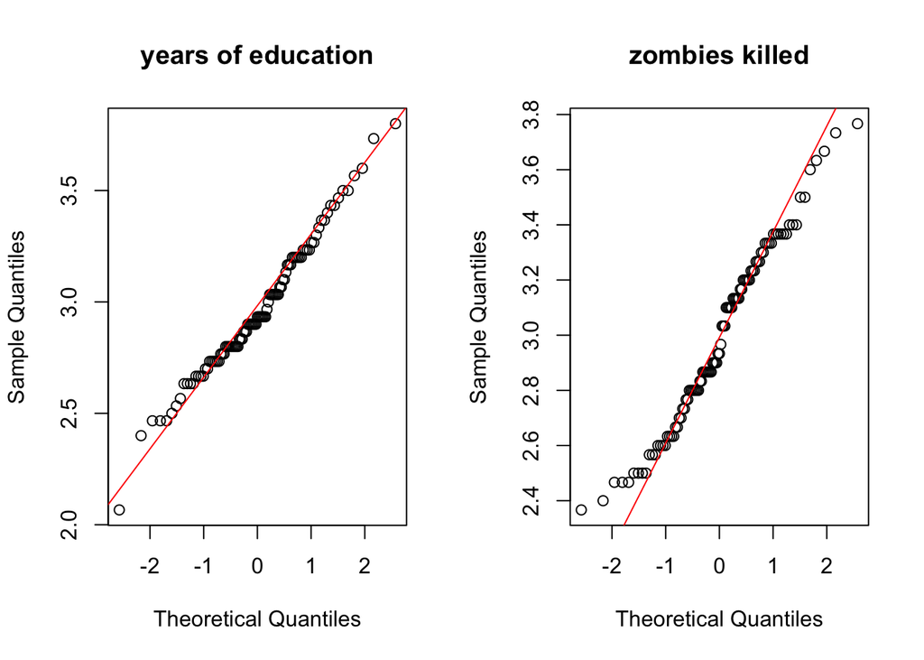

```r
qqnorm(s_yoesd$mean, main = "years of education") #no longer a staircase, now has a linear form
qqline(s_yoesd$mean, col = "red")
qqnorm(s_zksd$mean, main = "zombies killed") # ""
qqline(s_zksd$mean, col = "red")
```

#### The sample distribution of all quantitative variables appear to be normally distributed. The amazing feature about the Central Limit Theorem, is that even if data is not normally distributed, sampling distributions of this data will take this form (a normal distribution form). As stated in class, the sampling distributions appear normal and this is because our sample size is large enough and our samples are independent and identically distributed.